# QTW FINAL CASE STUDY SUMMER 2020

```r
#data manipulation
library(tidyverse)
library(dplyr)
#visualization
library(ggplot2)
library(skimr)
library(corrplot)
#prediction
library(RSNNS)
```

data from - https://smu.box.com/s/k9x192jxm39enjw2wx8ouw2kopx33l32 classify column ‘y’ using features x0-x49 minimize cost on a theorhetical unknown dataset, where false positive = -10$ false negative = -500$ true positive/negative = -0$

include- confusion plot with costs average/predicted as a model metric

```r
#file_name = file.choose()
#data_raw = read.csv(file_name)
data_raw = read.csv('D:/SMU/DS 7333 Quantify The World/qtw_final_project.csv')
```

cleaning section and eda

```r
#eda with skimr
skim(data_raw) %>% dplyr::select(skim_type, skim_variable, n_missing)
```

```
-- Data Summary ------------------------
                           Values
Name                       data_raw
Number of rows             160000
Number of columns          51
_______________________
Column type frequency:
  character                5
  numeric                  46
________________________
Group variables            None

-- Variable type: character ------------------------------------------------------------------------------------------
# A tibble: 5 x 2
  skim_variable n_missing
```

[output cut: 57 more lines]

```r
skim(data_raw) %>% dplyr::select(skim_type, skim_variable, numeric.mean)
```

```
-- Data Summary ------------------------
                           Values
Name                       data_raw
Number of rows             160000
Number of columns          51
_______________________
Column type frequency:
  character                5
  numeric                  46
________________________
Group variables            None

-- Variable type: character ------------------------------------------------------------------------------------------
# A tibble: 5 x 1
  skim_variable
```

[output cut: 57 more lines]

most columns look like they are missing a few, less than triple digits. Likely not significant next to the 160K total rows

```r
#remove rows with na
data_v1 <- data_raw[complete.cases(data_raw), ]
dim(data_v1)
```

```
[1] 158534     51
```

from 160,000 to 158,534, removing all rows with NA loses 1,500 ish rows, or 0.9% of data

```r
#col 37 is dollar amounts stored as characters, need to convert
data_v1$x37 <- as.numeric(substr(data_v1$x37, 2, nchar(data_v1$x37))) #index string with substring to cut out the dollar sign and convert to numeric
#same for col 32
data_v1$x32 <- as.numeric(substr(data_v1$x32, 1, nchar(data_v1$x32)-1)) #same thing
```

ok, now we have numeric values for x37 instead of characters, run na removal again

```r
data_v1 <- data_v1[complete.cases(data_v1), ]
dim(data_v1)
```

```
[1] 158480     51
```

```r
# #isolate numeric columns only
# numeric_only <- data_v1[, unlist(lapply(data_v1, is.numeric))]
# #corrplot
# cor1 <- cor(numeric_only)
# corrplot(cor1, method = 'circle')
# ggsave('corplot1.png', device = 'png', plot = last_plot(), dpi = 300, width = 10, height = 10, units = 'in')
# #saves to wherever getwd() is pointing
```

also note that rows 2/6 and 38/41 are closely correlated, may be able to eliminate one

```r
#looking at number of categorical variables in each non-numeric column
non_numeric_only <- data_v1[, !unlist(lapply(data_v1, is.numeric))]

for(i in 1:length(non_numeric_only)){
  print(table(non_numeric_only[, i]))
}
```

```
        america    asia  euorpe
     28    4420  137651   16381

            Apr     Aug     Dev     Feb January    July     Jun     Mar     May     Nov     Oct   sept.
     30    6701   29125      23     139       9   45140   40922    1221   21711     332    2385   10742

             friday    monday   thurday   tuesday wednesday
       30       556       484     29172     27697    100541
```

not too many labels to one hot encode

```r
#assign numeric values to each reigon, asia, america, 'euorpe'
temp_labels <- unique(non_numeric_only$x24)
tc = non_numeric_only$x24 #target column
for(i in 1:length(tc)){
  if(tc[i] == temp_labels[1]){
    encoded_value <- 1
  }
  if(tc[i] == temp_labels[2]){
    encoded_value <- 2
  }
  if(tc[i] == temp_labels[3]){
    encoded_value <- 3
  }
  if(tc[i] == temp_labels[4]){
    encoded_value <- 4
  }
  else{
    #encoded_value <- NA
  }
  tc[i] <- encoded_value
}
temp_labels
```

```
[1] "euorpe"  "asia"    "america" ""
```

```r
table(tc)
```

```
tc
     1      2      3      4
 16381 137651   4420     28
```

```r
reigon_encoded <- as.numeric(tc) #store for later integration
```

```r
#monthly encoding
temp_labels <- unique(non_numeric_only$x29)
tc = non_numeric_only$x29 #target column
for(i in 1:length(tc)){
  if(tc[i] == 'January'){
    encoded_value <- 1}
  if(tc[i] == 'Feb'){
    encoded_value <- 2}
  if(tc[i] == 'Mar'){
    encoded_value <- 3}
  if(tc[i] == "Apr"){
    encoded_value <- 4}
  if(tc[i] == "May"){
    encoded_value <- 5}
  if(tc[i] == "Jun"){
    encoded_value <- 6}
  if(tc[i] == "July"){
    encoded_value <- 7}
  if(tc[i] == "Aug"){
    encoded_value <- 8}
  if(tc[i] == "sept."){
    encoded_value <- 9}
  if(tc[i] == "Oct"){
    encoded_value <- 10}
  if(tc[i] == "Nov"){
    encoded_value <- 11}
  if(tc[i] == "Dev"){
    encoded_value <- 12}
  if(tc[i] == ""){
    encoded_value <- 13}

  tc[i] <- encoded_value
}
temp_labels
```

```
 [1] "July"    "Aug"     "Jun"     "May"     "sept."   "Apr"     "Nov"     "Oct"     ""        "Mar"     "Feb"
[12] "Dev"     "January"
```

```r
table((non_numeric_only$x29))
```

```
            Apr     Aug     Dev     Feb January    July     Jun     Mar     May     Nov     Oct   sept.
     30    6701   29125      23     139       9   45140   40922    1221   21711     332    2385   10742
```

```r
table(tc)
```

```
tc
    1    10    11    12    13     2     3     4     5     6     7     8     9
    9  2385   332    23    30   139  1221  6701 21711 40922 45140 29125 10742
```

```r
month_encoded <-as.numeric(tc) #store for later integration
```

ok, sorted months match up

```r
#day of week encoding
temp_labels <- unique(non_numeric_only$x30)
tc = non_numeric_only$x30 #target column
for(i in 1:length(tc)){
  if(tc[i] == 'monday'){
    encoded_value <- 1}
  if(tc[i] == 'tuesday'){
    encoded_value <- 2}
  if(tc[i] == 'wednesday'){
    encoded_value <- 3}
  if(tc[i] == 'thurday'){
    encoded_value <- 4}
  if(tc[i] == 'friday'){
    encoded_value <- 5}
  if(tc[i] == ''){
    encoded_value <- 6}
  tc[i] <- encoded_value
}
temp_labels
```

```
[1] "tuesday"   "wednesday" "thurday"   "monday"    "friday"    ""
```

```r
table((non_numeric_only$x30))
```

```
             friday    monday   thurday   tuesday wednesday
       30       556       484     29172     27697    100541
```

```r
table(tc)
```

```
tc
     1      2      3      4      5      6
   484  27697 100541  29172    556     30
```

```r
weekday_encoded <-as.numeric(tc) #store for later integration
```

‘thurday’ <—– anyways, same matchups, looks correct

now integrate these values back into another version of the data in order to do correlation analysis on all numerics

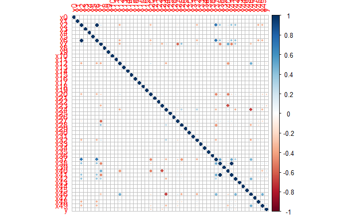

```r
data_v2 <- data_v1
data_v2$x24 <- reigon_encoded
data_v2$x29 <- month_encoded
data_v2$x30 <- weekday_encoded

numeric_only <- data_v2[, unlist(lapply(data_v2, is.numeric))]
cor2 <- cor(numeric_only)
corrplot(cor2, method = 'circle')
```

hm ok not much of a difference, 24, 29, and 30 don’t have any strong correlation with y, but might be useful to have everything numeric anyways

NN classification test 1

```r
#stuttgart neural network simulator test
#where size = units in hidden layer

inputs_v3 <- data_v2[, -data_v2$y]
target_v3 <- data_v2$y
data_v4 <- splitForTrainingAndTest(inputs_v3, target_v3, ratio = 0.3)

model1 <- mlp(data_v4$inputsTrain, data_v4$targetsTrain, size = 5, learnFuncParams = c(0.1), maxit = 50, inputsTest = data_v4$inputsTest, targetsTest = data_v4$targetsTest)
```

```r
summary(model1)
```

[output not shown]

[output cut: 67 more lines]

[output not shown]

```r
model1
```

```
Class: mlp->rsnns
Number of inputs: 50
Number of outputs: 1
Maximal iterations: 50
Initialization function: Randomize_Weights
Initialization function parameters: -0.3 0.3
Learning function: Std_Backpropagation
Learning function parameters: 0.1
Update function:Topological_Order
Update function parameters: 0
Patterns are shuffled internally: TRUE
Compute error in every iteration: TRUE
Architecture Parameters:
$size
[1] 5

All members of model:
 [1] "nInputs"               "maxit"                 "initFunc"              "initFuncParams"
 [5] "learnFunc"             "learnFuncParams"       "updateFunc"            "updateFuncParams"
 [9] "shufflePatterns"       "computeIterativeError" "snnsObject"            "archParams"
[13] "IterativeFitError"     "IterativeTestError"    "fitted.values"         "fittedTestValues"
[17] "nOutputs"
```

```r
extractNetInfo(model1)
```

| name | value |
| --- | --- |
| no. of units | 56 |
| no. of connections | 255 |
| no. of unit types | 0 |
| no. of site types | 0 |
| learning function | Std_Backpropagation |
| update function | Topological_Order |

| unitNo | unitName | unitAct | unitBias | type | posX | posY | posZ | actFunc | outFunc | sites |
| --- | --- | --- | --- | --- | --- | --- | --- | --- | --- | --- |
| 1 | Input_x1 | -4.127732e-01 | 0.104795605 | UNIT_INPUT | 1 | 0 | 0 | Act_Identity | Out_Identity |  |
| 2 | Input_x2 | -1.091141e+01 | -0.103982523 | UNIT_INPUT | 2 | 0 | 0 | Act_Identity | Out_Identity |  |
| 3 | Input_x3 | -5.633629e+00 | -0.245965347 | UNIT_INPUT | 3 | 0 | 0 | Act_Identity | Out_Identity |  |
| 4 | Input_x4 | -4.028154e+00 | -0.220520556 | UNIT_INPUT | 4 | 0 | 0 | Act_Identity | Out_Identity |  |
| 5 | Input_x5 | 1.593943e+01 | -0.275888681 | UNIT_INPUT | 5 | 0 | 0 | Act_Identity | Out_Identity |  |
| 6 | Input_x6 | -1.586437e+01 | 0.096283048 | UNIT_INPUT | 6 | 0 | 0 | Act_Identity | Out_Identity |  |
| 7 | Input_x7 | -4.638819e+01 | -0.209741175 | UNIT_INPUT | 7 | 0 | 0 | Act_Identity | Out_Identity |  |
| 8 | Input_x8 | 1.833947e+01 | -0.288017988 | UNIT_INPUT | 8 | 0 | 0 | Act_Identity | Out_Identity |  |
| 9 | Input_x9 | -4.575499e+00 | 0.143066347 | UNIT_INPUT | 9 | 0 | 0 | Act_Identity | Out_Identity |  |
| 10 | Input_x10 | -2.976210e+00 | 0.270278513 | UNIT_INPUT | 10 | 0 | 0 | Act_Identity | Out_Identity |  |

[output cut: 46 more lines]

[output not shown]

[output cut: 55 more lines]

[output not shown]

```r
confusionMatrix(data_v4$targetsTrain, fitted.values(model1))
```

[output not shown]

[output cut: 326 more lines]

[output not shown]

```r
#confusionMatrix(data_v4$targetsTest, predictions)
```

hmm outputs aren’t coming out as 1/0, maybe need to switch to categorical??